# UDACITY DATA WRANGLING PROJECT_-Copy1

#### Question 1: Which Dog stage is liked the most?

NB: Every inference is based on the sample(cleaned data) we are working with for the purpose this analysis

```python
fav = pd.DataFrame(Data.groupby('dog_type').sum()['favorite_count'].sort_values(ascending=False).round())
```

```python
fav
```

| dog_type | favorite_count |
| --- | --- |
| pupper | 1566619.0 |
| doggo | 1219452.0 |
| puppo | 522650.0 |
| floofer | 109611.0 |

```python
pd.DataFrame(Data.groupby('dog_type').sum()['favorite_count'].sort_values(ascending=False).round())
```

[output not shown]

The dog stage is most liked by the twitter community is the Pupper,although the tweets that had to do with the pupper had highest favourites, we have to check if it is as a function of the amount of pupper tweets that featured in the final clean data

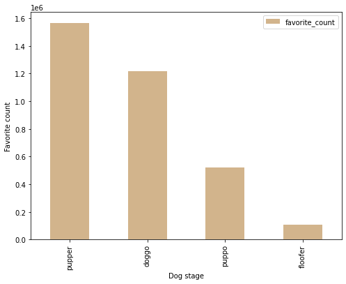

```python
#Visualizing this on a bar chart
fav.plot(kind='bar',ylabel='Favorite count',xlabel='Dog stage', figsize=(8,6), color ='tan');
```

#### Question 2: Which Dog stage is rated the highest?

```python
rate = pd.DataFrame(Data.groupby('dog_type').mean()['rating_numerator'].sort_values(ascending=False).round(2))
```

```python
rate
```

| dog_type | rating_numerator |
| --- | --- |
| puppo | 12.04 |
| doggo | 11.89 |
| floofer | 11.88 |
| pupper | 10.65 |

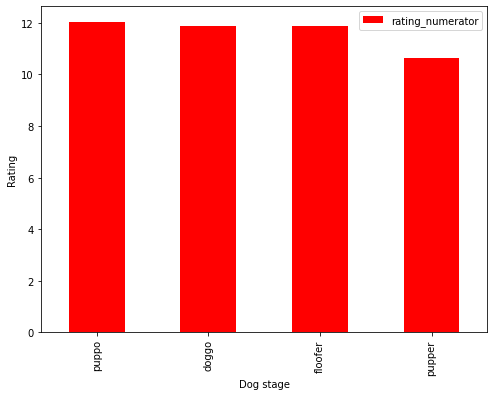

```python
rate.plot(kind='bar',ylabel='Rating',xlabel='Dog stage', figsize=(8,6), color ='red');
```

Albeit not by a landslide, the puppo dog type edges the other dog types in terms of rating. This would not be totally expected because of the insight in the first chart, so we still need to dig further.

#### Question 3: Let's further validate that the most liked dog stage being pupper is affected by the count of tweets for the pupper dog stage

```python
count = pd.DataFrame(Data['dog_type'].value_counts(normalize=True).sort_values(ascending=False).round(2)*100)
```

```python
count
```

|  | dog_type |
| --- | --- |
| pupper | 69.0 |
| doggo | 21.0 |
| puppo | 8.0 |
| floofer | 3.0 |

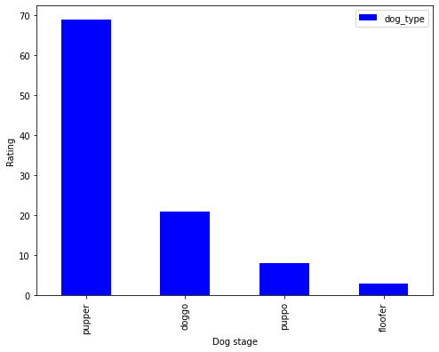

```python
count.plot(kind='bar',ylabel='Rating',xlabel='Dog stage', figsize=(8,6), color ='blue');
```

#### What day of the week had the most tweet engagement?

```python
day_count = pd.DataFrame(Data.groupby('day').sum()['favorite_count'].sort_values(ascending=False).round(2))
```

```python
day_count
```

| day | favorite_count |
| --- | --- |
| Saturday | 684550.0 |
| Wednesday | 626139.0 |
| Monday | 544955.0 |
| Thursday | 426057.0 |
| Tuesday | 415965.0 |
| Sunday | 401311.0 |
| Friday | 319355.0 |

```python
day_count_rt = pd.DataFrame(Data.groupby('day').sum()['retweet_count'].sort_values(ascending=False).round(2))
```

```python
day_count_rt
```

| day | retweet_count |
| --- | --- |
| Saturday | 290745.0 |
| Wednesday | 211878.0 |
| Monday | 169316.0 |
| Thursday | 144112.0 |
| Tuesday | 121225.0 |
| Sunday | 118571.0 |
| Friday | 107582.0 |

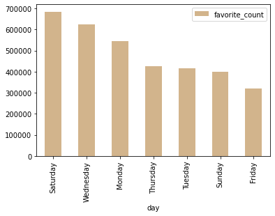

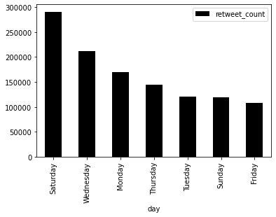

```python
day_count.plot(kind = 'bar', label = 'favorite',color ='tan');
day_count_rt.plot(kind = 'bar',label = 'retweet',color='black');
plt.show()
```

## Conclusion

- The most liked dog stage is the pupper stage, albeit heavily influenced by the number of tweets featured in the dataset
- Tweets should be made on saturdays as the day records more engagements in terms of retweets and favorites